# ReSources Worked Examples

Three Progressive Examples for Dietary Reconstruction

Archaeological Isotope Laboratory

2026-02-22

## Training Objectives

By the end of this session, you will:

1. Set up three progressively complex mixing models in ReSources
2. Understand when to include components, concentrations, and offsets
3. Interpret different estimate types (source contributions, by-proxy, components)
4. Recognize how routing affects dietary proportion estimates
5. Apply these skills to your own archaeological datasets

**Tip**

**Hands-on approach:** Follow along on your computer as we work through each example together

## Overview: Three Examples

### Example 1

**Simplest Case**

- 1 consumer
- 2 sources
- 1 isotope (δ<sup>13</sup>C)
- No offsets
- No components
- No concentrations

⏱️ **~2 minutes**

### Example 2

**Adding Realism**

- 1 consumer
- 2 sources
- 2 isotopes
- **✓ Offsets**
- **✓ Concentrations**
- No components

⏱️ **~3 minutes**

### Example 3

**Gold Standard**

- 1 consumer
- 2 sources
- 2 isotopes
- **✓ Offsets**
- **✓ Concentrations**
- **✓ Components**

⏱️ **~5 minutes**

# Example 1

## The Simplest Case

## Example 1: Scenario

**Research Question:** What proportions of Source 1 vs. Source 2 did the consumer eat?

**Consumer:**

- δ<sup>13</sup>C = −15.0 ± 0.5 ‰

**Sources:**

- Source 1: δ<sup>13</sup>C = −20.0 ± 1.0 ‰
- Source 2: δ<sup>13</sup>C = −10.0 ± 1.0 ‰

**Model Settings:**

- ✗ No components
- ✗ No concentrations
- ✗ No offsets (Δ = 0)

**Why unrealistic?**

Real bone collagen *always* requires trophic enrichment factors. But this teaches the basics!

## The Mixing Equation

Since there are no offsets, components, or concentrations:

$$\delta^{13}C_{\text{consumer}} = f_1 \cdot \delta^{13}C_{\text{Source1}} + f_2 \cdot \delta^{13}C_{\text{Source2}}$$

$$f_1 + f_2 = 1$$

**Algebraic solution:**

$$\begin{aligned}
-15 &= f_1 \cdot (-20) + (1-f_1) \cdot (-10) \\
f_1 &= 0.5 \quad (50\%)\\
f_2 &= 0.5 \quad (50\%)
\end{aligned}$$

**Note**

Consumer sits **halfway** between sources → 50/50 split

## Setting Up in ReSources

- Step 1: Model Options
- Step 2: Target Data
- Step 3: Sources
- Step 4: Run

Navigate to: **Core Model Options**

- Model type: **Update model** ✓
- Components: **UNCHECK** ✗
- Concentrations: **UNCHECK** ✗
- Target offset: **UNCHECK** ✗

Navigate to: **Data → Target**

| Individual | d13C (mean) | d13C (SD) |
| --- | --- | --- |
| target1 | -15.0 | 0.5 |

**Tip:** Copy from Excel → Click outside table → Ctrl+V

Navigate to: **Data → Sources → d13C**

| Source | Mean | SD |
| --- | --- | --- |
| Source1 | -20.0 | 1.0 |
| Source2 | -10.0 | 1.0 |

Click **“Run Model”**

Wait ~1 minute for compilation + sampling

## Example 1: Results

**Expected Output:**

| Source | Mean | 95% CI |
| --- | --- | --- |
| Source1 | 0.50 | [0.38, 0.62] |
| Source2 | 0.50 | [0.38, 0.62] |

**Interpretation:**

- Both sources contribute equally (50/50)
- ±12% uncertainty from measurement error
- Bayesian inference quantifies this uncertainty

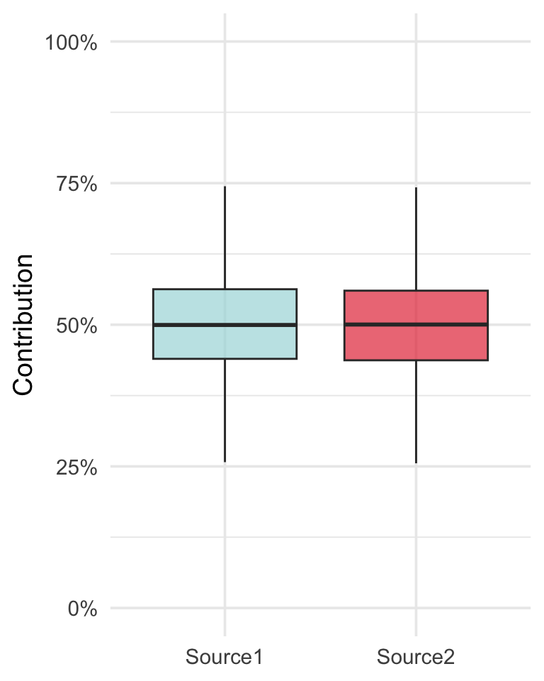

## Key Lesson from Example 1

**Consumer position determines proportions**

If consumer is:

- Halfway between sources → 50/50
- Closer to Source 1 → Higher f<sub>1</sub>
- Closer to Source 2 → Higher f<sub>2</sub>

**Warning**

**Remember:** This simple model is *pedagogical only*. Real bone collagen analysis requires offsets!

# Example 2

## Adding Offsets and Concentrations

## Example 2: Scenario

Now we add **two critical features**:

**Consumer:**

**Sources:**

| Source | δ¹³C | δ¹⁵N | Protein % |
| --- | --- | --- | --- |
| Source 1 | −20 ±1 | +5 ±1 | 20 ±5 |
| Source 2 | −10 ±1 | +10 ±1 | 40 ±5 |

**Offsets (TEFs):**

- Δ<sup>13</sup>C = +1.0 ± 0.5 ‰
- Δ<sup>15</sup>N = +5.5 ± 0.5 ‰

**Model Settings:**

- ✗ No components (yet!)
- ✓ **Concentrations**
- ✓ **Offsets**

## Why Offsets Matter

**Without offsets:** Consumer values seem incompatible with sources

**Raw sources:**

- Source 1: δ<sup>15</sup>N = +5 ‰
- Source 2: δ<sup>15</sup>N = +10 ‰

**Consumer:** δ<sup>15</sup>N = +13 ‰

❌ **Problem:** +13 is *above* both sources!

**After applying offset** (+5.5 ‰):

- Source 1: +5 + 5.5 = **+10.5 ‰**
- Source 2: +10 + 5.5 = **+15.5 ‰**

**Consumer:** +13 ‰

✓ **Solution:** Now sits *between* sources

**Important**

**Trophic enrichment is a physical phenomenon**

Bone collagen is systematically enriched in heavy isotopes relative to diet. *Always* include TEFs!

## Why Concentrations Matter

Different foods have different **protein densities**:

**Scenario:** Eat 1 kg of each source

- Source 1: 1 kg × 20% = **0.2 kg protein**
- Source 2: 1 kg × 40% = **0.4 kg protein**
- Total: 0.6 kg protein

**Protein contribution:**

- Source 1: 0.2 / 0.6 = **33%**
- Source 2: 0.4 / 0.6 = **67%**

**Tip**

**Key insight**

Even though you ate **equal masses** (50/50), you consumed **unequal protein** (33/67)

For bone collagen (protein tissue), we care about *nutrient intake*, not food mass

## Setting Up Example 2

- Model Options
- Target Data
- Offsets
- Sources
- Concentrations

**Changes from Example 1:**

- ✓ **CHECK** “Include concentrations”
- ✓ **CHECK** “Constrain concentrations 0–100”
- ✓ **CHECK** “Include target offset”

**Two isotopes now:**

[output not shown]

**New table appears:**

| Proxy | Offset | SD |
| --- | --- | --- |
| d13C | +1.0 | 0.5 |
| d15N | +5.5 | 0.5 |

**Enter for each isotope separately:**

*d13C tab:* Source1 (−20, 1), Source2 (−10, 1)

*d15N tab:* Source1 (+5, 1), Source2 (+10, 1)

| Source | d13C | d15N |
| --- | --- | --- |
| Source1 | 20 ±5 | 20 ±5 |
| Source2 | 40 ±5 | 40 ±5 |

*(Same values for both proxies because measuring same nutrient: protein)*

## Example 2: Results

**Expected Output:**

| Source | Mean | 95% CI |
| --- | --- | --- |
| Source1 | 0.30 | [0.18, 0.44] |
| Source2 | 0.70 | [0.56, 0.82] |

**Why Source 2 dominates:**

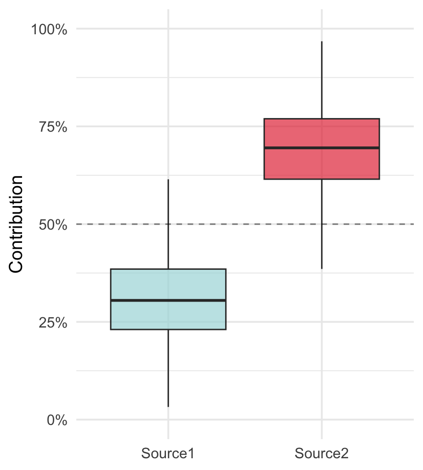

## Multiple Estimate Types

ReSources provides different perspectives on the same data:

| Estimate type | What it shows | Example 2 values |
| --- | --- | --- |
| **Source contributions** | Overall contribution to diet | S1: 30%, S2: 70% |
| **Contributions by d13C** | Carbon signal attribution | S1: 30%, S2: 70% |
| **Contributions by d15N** | Nitrogen signal attribution | S1: 32%, S2: 68% |

**Note**

**Why do they differ?**

Consumer sits at *different relative positions* in carbon vs. nitrogen space. Concentrations also affect how bulk food translates to nutrient contribution.

## Key Lessons from Example 2

1. **Two isotopes improve resolution** — δ<sup>15</sup>N distinguishes sources with similar δ<sup>13</sup>C
2. **Offsets are non-negotiable** — Without TEFs, consumer falls outside mixing space
3. **Concentrations adjust for protein density** — 40% protein source contributes more to collagen than 20% source, even if masses equal
4. **Multiple estimates provide different insights** — “Source contributions” ≠ “Contributions by nitrogen”

# Example 3

## Full Routed Mixing Model

## Example 3: The Complete Model

Now we implement **selective routing** of dietary components:

**Key Addition: Components**

- **Protein** — amino acids
- **CarbsLipids** — energy sources

Each has *different isotope values* within same food source

**Component Weights (Routing):**

- δ<sup>13</sup>C collagen: **74% protein**, 26% energy
- δ<sup>15</sup>N collagen: **100% protein**, 0% energy

**Why This Matters:**

Bone collagen is synthesized from dietary protein preferentially, *not* bulk diet

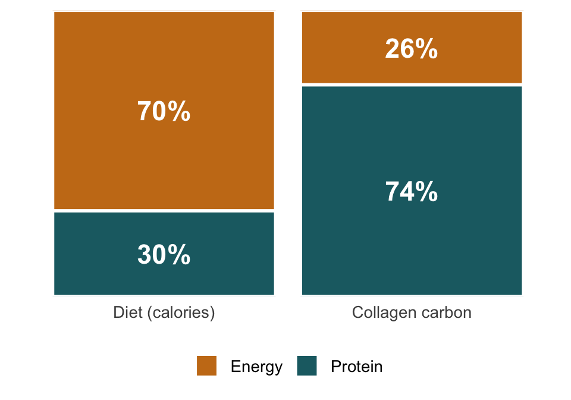

## Real-World Consequence

Imagine a population eating:

- **70% maize** (C<sub>4</sub> plant, δ<sup>13</sup>C ≈ −12 ‰) → energy
- **30% animal meat** (δ<sup>13</sup>C ≈ −21 ‰) → protein

**Unrouted model (Example 2) predicts:**

$$\delta^{13}C_{\text{collagen}} = 0.70 \times (-12) + 0.30 \times (-21) = -14.7 \text{ ‰}$$

**Routed model (Example 3) predicts:**

$$\delta^{13}C_{\text{collagen}} = 0.74 \times (-21) + 0.26 \times (-12) = -18.7 \text{ ‰}$$

**Important**

**4 ‰ difference!** Enough to completely change dietary interpretation

## Example 3: Data Structure

Sources now have **component-specific isotope values**:

| Source | δ¹³C (protein) | δ¹³C (carbs/lipids) | δ¹⁵N (protein) |
| --- | --- | --- | --- |
| Source 1 | −20 ± 1 | −19 ± 1 | +5 ± 1 |
| Source 2 | −10 ± 1 | −11 ± 1 | +10 ± 1 |

**Concentrations by component:**

| Source | Protein (%) | Carbs/Lipids (%) |
| --- | --- | --- |
| Source 1 | 20 ± 5 | 60 ± 5 |
| Source 2 | 40 ± 5 | 40 ± 5 |

## Setting Up Example 3

- Enable Components
- Components Table
- Sources (Changed!)
- Sources d15N
- Concentrations

**Critical change:**

Navigate to: **Core Model Options**

- ✓ **CHECK** “Include components”

This unlocks the **Components table**

**Define routing weights:**

| Proxy | Protein | CarbsLipids |
| --- | --- | --- |
| d13C | 0.74 | 0.26 |
| d15N | 1.00 | 0.00 |

⚠️ **Names must match** across all tables!

**Data → Sources → d13C tab:**

Now has columns for *both* components:

| Source | Protein | CarbsLipids |
| --- | --- | --- |
| Source1 | −20 ±1 | −19 ±1 |
| Source2 | −10 ±1 | −11 ±1 |

**Only protein** (no N in carbs/lipids):

| Source | Protein |
| --- | --- |
| Source1 | +5 ±1 |
| Source2 | +10 ±1 |

**Both components:**

| Source | Protein | CarbsLipids |
| --- | --- | --- |
| Source1 | 20 ±5 | 60 ±5 |
| Source2 | 40 ±5 | 40 ±5 |

## Example 3: Results

**Source Contributions:**

| Source | Mean | 95% CI |
| --- | --- | --- |
| Source1 | 0.35 | [0.21, 0.50] |
| Source2 | 0.65 | [0.50, 0.79] |

**NEW: Component Contributions**

| Component | Mean | 95% CI |
| --- | --- | --- |
| Protein | 0.45 | [0.38, 0.52] |
| CarbsLipids | 0.55 | [0.48, 0.62] |

**Interpreting Component Contributions:**

Of total nutrients consumed:

- 45% were protein
- 55% were carbs/lipids

This is a **new dietary insight** not available from unrouted models!

## Understanding Different Estimates

| Estimate type | What it shows | Use it to answer: |
| --- | --- | --- |
| **Source contributions** | Overall food contribution | “How much of each food did they eat?” |
| **Contributions by d15N** | Protein source contributions | “Where did their protein come from?” |
| **Contributions by d13C** | Mixed (protein + energy) | “Carbon signal attribution” |
| **Component contributions** | Protein vs. energy balance | “What was the protein/energy ratio?” |

**Tip**

**Pro tip:** For bone collagen, “Contributions by d15N” = protein contributions (since N is 100% protein-derived)

## Comparing All Three Examples

[output not shown]

## Key Lessons from Example 3

1. **Routing is essential** — Unrouted models misestimate protein contributions for bone collagen
2. **Component contributions unlock new insights** — Quantify protein vs. energy balance
3. **Nitrogen = protein** — “Contributions by d15N” directly shows protein sources
4. **More setup = more information** — Component-specific data yields richer dietary reconstructions
5. **This is the gold standard** — Always use routed models (ReSources, FRUITS) for archaeological collagen

# Practical Tips

## Copy-Paste Workflow

- The Trick
- Common Mistakes
- Pro Workflow
1. Always include **header row** when copying
2. **Click outside** the table in ReSources before pasting
3. Use **Ctrl+V** (or Paste button if Ctrl+V fails)
4. **Verify immediately** — check values transferred correctly

❌ Forgetting header row → columns misaligned

❌ Not clicking outside → paste goes nowhere

❌ Typos in names → “Proxy names do not match” error

Prepare **one Excel sheet** with all examples:

- Sheet 1: Example 1
- Sheet 2: Example 2
- Sheet 3: Example 3

Copy sections as needed during training

## Naming Conventions (Critical!)

**These names MUST match exactly across tables:**

**Proxy names:**

- ✓ “d13C” everywhere
- ✗ “d13C” vs “d 13C” (space!)
- ✗ “d13C” vs “D13C” (case!)

**Component names:**

- ✓ “Protein” everywhere
- ✗ “Protein” vs “protein”
- ✗ “CarbsLipids” vs “Carbs/Lipids”

**Where names must match:**

1. Target table headers
2. Sources table tabs/headers
3. Components table rows/headers
4. Offsets table rows
5. Concentrations table headers

**Warning**

**One typo = model won’t run**

## Troubleshooting Common Errors

| Error message | Cause | Fix |
| --- | --- | --- |
| “Proxy names do not match” | “d13C” spelled differently in tables | Check spelling in Target, Sources, Offsets |
| “Component names not found” | “Protein” doesn’t match “protein” | Ensure identical case/spelling |
| “Consumer outside mixing space” | Forgot offsets OR missing sources | Add TEFs or check source list |
| Nonsensical results (>100%) | Convergence failure | Increase iterations to 100,000 |
| Model won’t run | Data inconsistency | Check all table names match |

## Checking Convergence

After running, always check:

- Convergence Message
- Trace Plots
- Gelman-Rubin

Look for:

> “Convergence diagnostic (Geweke): **No convergence failures**”

If failures reported → increase iterations

Navigate: **Results → Diagnostics → Trace Plots**

✓ **Good:** “Hairy caterpillar” — rapid mixing, chains overlap

✗ **Bad:** Trending up/down — increase burn-in

✗ **Bad:** Chains separate — increase iterations or check data

For each parameter, should see:

- $\hat{R} < 1.1$ → converged ✓
- $\hat{R} > 1.1$ → not converged ✗

# Summary & Next Steps

## What You’ve Learned

✅ **Example 1:** Basic mixing equation — consumer position determines proportions

✅ **Example 2:** Why offsets and concentrations are essential for realistic models

✅ **Example 3:** How routing captures protein-selective collagen synthesis

✅ **Practical skills:** Data entry, copy-paste workflow, troubleshooting

✅ **Interpretation:** Different estimate types answer different questions

✅ **When to use which:** Unrouted (never for collagen) vs. Routed (always for collagen)

## Applying to Your Data

**Before analyzing your skeletal assemblage:**

1. **Screen collagen quality**
   - C:N ratios: 2.9–3.6
   - %C: 30–45%, %N: 11–16%
2. **Gather source reference data**
   - n ≥ 10–15 per source
   - Same site/period as consumers
3. **Justify TEF values**
   - Literature values with uncertainty
   - Conduct sensitivity analyses
4. **Document routing parameter**
   - λ = 0.74 ± 0.08 (human collagen default)
   - Cite: Fernandes et al. 2012

## Practice Exercises

**Try these on your own:**

1. **Modify Example 3**
   - Change consumer to: δ<sup>13</sup>C = −12 ‰, δ<sup>15</sup>N = +15 ‰
   - Predict: Which source will dominate?
   - Run model to check
2. **Three-source model**
   - Add a third source to Example 2
   - Observe how credible intervals widen (underdetermined)
3. **Sensitivity analysis**
   - Run Example 3 with λ = 0.70, then λ = 0.80
   - Compare results — how much do they differ?
4. **Your own data**
   - Input one individual from your assemblage
   - Follow Example 3 template

## Key References

**ReSources:**

- Fernandes et al. (2021) *Science Advances* **7**, eabg5791 — the ReSources paper

**Routing experiments:**

- Ambrose & Norr (1993) — controlled diet experiments
- Jim et al. (2006) *Br J Nutr* **95**, 1055–1062 — macronutrient routing
- Fernandes et al. (2012) *Archaeol Anthropol Sci* **4**, 291–301 — routing parameter

**Best practices:**

- Phillips et al. (2014) *Can J Zool* **92**, 823–835 — mixing model pitfalls

## Getting Help

**After today’s training:**

**Resources:**

**Support:**

**Tip**

**Remember:** Wide credible intervals aren’t failure — they’re honest uncertainty quantification!

## Questions?

Let’s work through the examples together

**Open ReSources on your computer and follow along…**